# Reproducible Research: Peer Assessment 1

This report provides a brief analysis of data from a personal activity monitoring device. Worn by an anonymous individual, data were collected from this device at 5 minute intervals spanning the months of October and November, 2012. The collected data include the number of steps taken during each interval.

The R scripts referenced in this document place output in the current working directory. The scripts use the data and figures sub-directories for storing the source data and generated figures respectively.

## Loading and preprocessing the data

```r
library(knitr)
# Set the following global value to ensure code is displayed by default
opts_chunk$set(echo=TRUE)
```

#### Load the data

```r
## Housekeeping
##   Make sure necessary directories are in place
if (!file.exists("data")) {
    dir.create("data")
}
if (!file.exists("figures")) {
    dir.create("figures")
}
## Fetch the data if necessary
if (!file.exists("./activity.zip")) {
    fileUrl <- "http://d396qusza40orc.cloudfront.net/repdata%2Fdata%2Factivity.zip"
    download.file(fileUrl, destfile = "./activity.zip", method = "curl")
}
if (!file.exists("./data/activity.csv")) {
    unzip("./activites.zip", exdir ="./data")
}

## Read in the data file
activity <- read.csv("./data/activity.csv", na.strings = "NA")
```

#### Pre-process the data

```r
activity$date <- as.Date(activity$date, format="%Y-%m-%d")
```

## What is mean total number of steps taken per day?

For this part of the evaluation, we can ignore the missing values in the dataset.

#### Histogram

Histogram of the total number of steps taken each day.

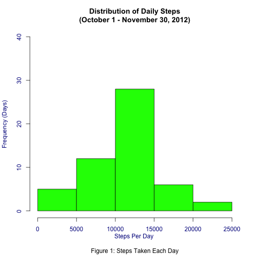

```r
library(plyr)
## Sum the steps by day
daily <- ddply(activity,~date,summarise,steps=sum(steps))
hist(daily$steps, col="green",
     main="Distribution of Daily Steps\n(October 1 - November 30, 2012)",
     col.lab="darkblue", col.axis="darkblue",
     xlab="Steps Per Day \n",
     ylab="Frequency (Days)",
     ylim= c(0,40),
     sub="Figure 1: Steps Taken Each Day",
     freq=TRUE)
```

```r
# Copy the plot to a PNG file in the figures/ subdirectory
dev.copy(png, file = "figures/fig01_hist.png",
         width=480, height=480, units="px")
```

```r
dev.off()
```

#### Mean and median

Next. we calculate and report the mean and median total number of steps taken per day.

```r
mean.steps.per.day <- mean(daily$steps, na.rm=TRUE)
median.steps.per.day <- median(daily$steps, na.rm=TRUE)
cat("Total Steps Per Day ##",
    "\nMean: ", mean.steps.per.day,
    "\nMedian: ", median.steps.per.day)
```

```
## Total Steps Per Day ##
## Mean:  10766
## Median:  10765
```

## What is the average daily activity pattern?

#### Plot

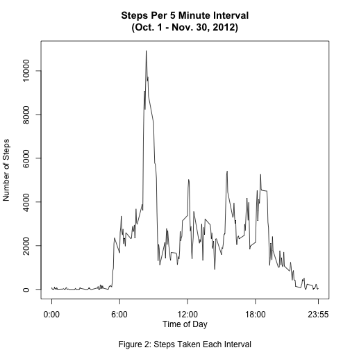

```r
library(plyr)
## Sum the steps by interval
by.interval <- ddply(activity,~interval,
                     summarise,steps=sum(steps, na.rm=TRUE))
plot(by.interval$interval, by.interval$steps,
     type="l",
     xlab="Time of Day\n",
     sub="Figure 2: Steps Taken Each Interval",
     ylab="Number of Steps",
     xaxt = 'n',
          main="Steps Per 5 Minute Interval
(Oct. 1 - Nov. 30, 2012)")
axis(1, labels = c('0:00', '6:00', '12:00', '18:00', '23:55'),
     at = c(0, 600, 1200, 1800, 2355))
```

```r
# Copy the plot to a PNG file in the figures/ subdirectory
dev.copy(png, file = "figures/fig02_interval_plot.png",
         width=480, height=480, units="px")
```

```r
dev.off()
```

#### Greatest interval

```r
max.int <- by.interval[by.interval$steps == max(by.interval$steps,
                                                na.rm=TRUE), ]
cat ("The interval with the greatest number of steps (",
     max.int$steps , ") is: ", max.int$interval, sep="")
```

```
## The interval with the greatest number of steps (10927) is: 835
```

## Imputing missing values

There are a number of days/intervals that are missing values (coded as NA). The presence of missing days may introduce bias into some calculations or summaries of the data.

#### Missing values

To determine the significance of missing values, we must first calculate and report the total number of missing values in the dataset (i.e. the total number of rows with NAs)

```r
library(plyr)
nas <- count(activity[activity$steps=="NA",])
cat("The total number missing values in the dataset is: ", nas$freq)
```

```
## The total number missing values in the dataset is:  2304
```

#### Strategy

A simple strategy for filling in all of the missing values in the dataset is to replace those values with averages across each 5-minute interval. We will do so for both the mean and the median so as to observe the effect of each.

#### New dataset

First we must create new datasets that are equal to the original dataset but with the missing data filled in.

```r
library(plyr)
# replace NAs with the mean number of steps over the coresponding interval
impute.by.mean <- function(x) replace(x, is.na(x), mean(x, na.rm = TRUE))
impute.by.median <- function(x) replace(x, is.na(x), median(x, na.rm = TRUE))
# New dataset imputed by interval mean
newdata <- ddply(activity, ~ interval, transform,
                 steps = impute.by.mean(steps))
# New dataset imputed by interval median
newdata2 <- ddply(activity, ~ interval, transform,
                 steps = impute.by.median(steps))
```

#### Histograms and report

To observe the results, we'll make a histogram of the total number of steps taken each day. Then, we'll calculate and report the mean and median total number of steps taken per day.

Imputing with the mean shows an increase in the overall number of steps taken (see the histogram in Figure 3 below), but the overall distribution mirrors the result gleened in the estimate (Figure 1).

This is confirmed with with by no change reported between the mean of the estimate and the imputed data. Similarly, the difference in the median (for the imputed mean) is insignificant.

However, when the median across the intervals is used to impute the missing data, the impact is more prononced with a slight flattening of the histogram (Figure 4) and lowering of the reported averages.

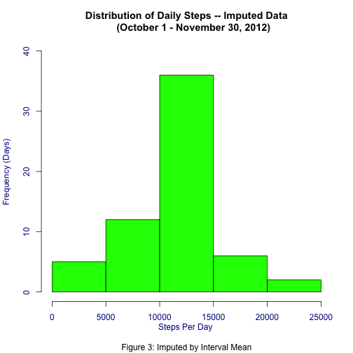

```r
library(plyr)
## Sum the steps by day
daily <- ddply(newdata,~date,summarise,steps=sum(steps))
hist(daily$steps, col="green",
     main="Distribution of Daily Steps -- Imputed Data
     (October 1 - November 30, 2012)",
     col.lab="darkblue", col.axis="darkblue",
     xlab="Steps Per Day \n",
     ylab="Frequency (Days)",
     ylim= c(0,40),
     sub="Figure 3: Imputed by Interval Mean",
     freq=TRUE)
```

```r
# Copy the plot to a PNG file in the figures/ subdirectory
dev.copy(png, file = "figures/fig03_mean_imputed_hist.png",
         width=480, height=480, units="px")
```

```r
dev.off()
```

```r
mean.steps.per.day <- mean(daily$steps, na.rm=F)
median.steps.per.day <- median(daily$steps, na.rm=F)
cat("Total Steps Per Day ##",
    "\nMean: ", mean.steps.per.day,
    "\nMedian: ", median.steps.per.day)
```

```
## Total Steps Per Day ##
## Mean:  10766
## Median:  10766
```

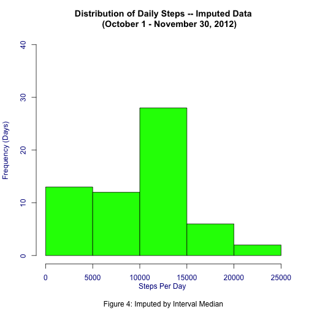

```r
daily <- ddply(newdata2,~date,summarise,steps=sum(steps))
hist(daily$steps, col="green",
     main="Distribution of Daily Steps -- Imputed Data
     (October 1 - November 30, 2012)",
     col.lab="darkblue", col.axis="darkblue",
     xlab="Steps Per Day \n",
     ylab="Frequency (Days)",
     ylim= c(0,40),
     sub="Figure 4: Imputed by Interval Median",
     freq=TRUE)
```

```r
# Copy the plot to a PNG file in the figures/ subdirectory
dev.copy(png, file = "figures/fig04_median_imputed_hist.png",
         width=480, height=480, units="px")
```

```r
dev.off()
```

```r
mean.steps.per.day <- mean(daily$steps, na.rm=F)
median.steps.per.day <- median(daily$steps, na.rm=F)
cat("Total Steps Per Day ##",
    "\nMean: ", mean.steps.per.day,
    "\nMedian: ", median.steps.per.day)
```

```
## Total Steps Per Day ##
## Mean:  9504
## Median:  10395
```

## Are there differences in activity patterns between weekdays and weekends?

Using the dataset with the filled-in missing values (imputed with mean) we now compare the subject's activity between weekends and weekdays.

#### New factor variable

```r
# add a new column to newdata
newdata <- cbind (newdata, day="day", stringsAsFactors=FALSE)
# populate the new column with "weekend" or "weekday"
for (i in 1:length(newdata$interval)) {
    if (as.POSIXlt(newdata[i,]$date)$wday == 0 ||
        as.POSIXlt(newdata[i,]$date)$wday == 1) {
    newdata[i,]$day <- "weekend"
    } else {
        newdata[i,]$day <- "weekday"
    }
}
```

#### Panel plot

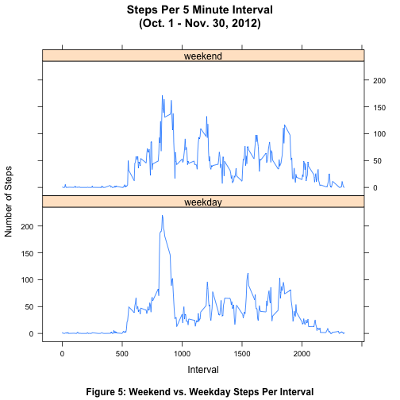

```r
library(stats)
library(lattice)
# Group the averages by weekend & weekday for each interval
by.day.int <- aggregate(steps ~ day + interval , data = newdata, mean)

xyplot(steps ~ interval|day, data=by.day.int,
       ylab = "Number of Steps",
       xlab = "Interval",
       type = "l",
       layout=c(1,2),
       sub="\nFigure 5: Weekend vs. Weekday Steps Per Interval",
       main = "Steps Per 5 Minute Interval\n(Oct. 1 - Nov. 30, 2012)")
```

```r
# Copy the plot to a PNG file in the figures/ subdirectory
dev.copy(png, file = "figures/fig05_weekend_v_weekday_plot.png",
         width=480, height=480, units="px")
```

```r
dev.off()
```